# Checks after review Cog and Emotion

Peris-Yague et al. 2023

12/5/2023

# *Plot E and E-1 mean recall*

The table and plot below show the mean recall for each word (E oddballs and E-1 items).

| item_who | word_who | variable | n | mean | sd |
| --- | --- | --- | --- | --- | --- |
| emo_minus_one | ahogado | recall | 70 | 0.371 | 0.487 |
| eo | ahogado | recall | 70 | 0.486 | 0.503 |
| emo_minus_one | amputaci�n | recall | 70 | 0.443 | 0.500 |
| eo | amputaci�n | recall | 70 | 0.757 | 0.432 |
| emo_minus_one | asesino | recall | 70 | 0.457 | 0.502 |
| eo | asesino | recall | 70 | 0.586 | 0.496 |
| emo_minus_one | asfixia | recall | 70 | 0.443 | 0.500 |
| eo | asfixia | recall | 70 | 0.614 | 0.490 |
| emo_minus_one | ceguera | recall | 70 | 0.357 | 0.483 |
| eo | ceguera | recall | 70 | 0.414 | 0.496 |

[output cut: 30 more lines]

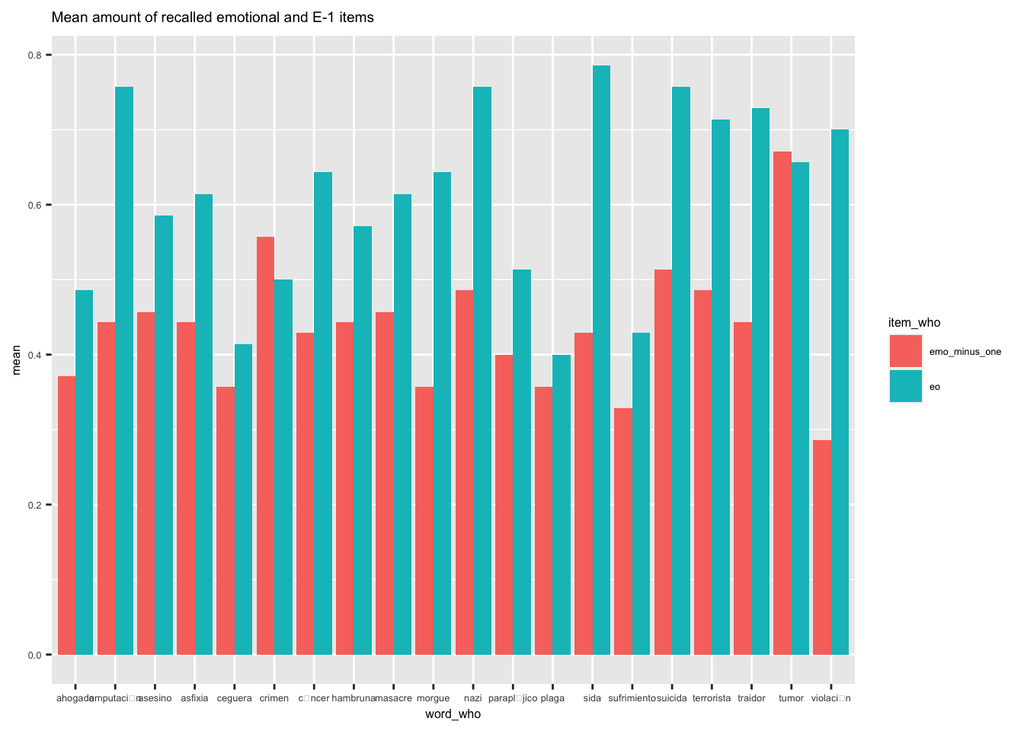

# *Median-split the data between high and low recall E oddballs*

We now have done a median-split of the data of the mean recall of each E oddball.

The histogram shows the distribution of the mean recall of all 20 items.

A median split of the data shows a median value of 0.628.

We then plotted E and E-1 recall for high (>0.62) vs. low (<0.62) recall items showing no differences in E-1 recall in the two groups.

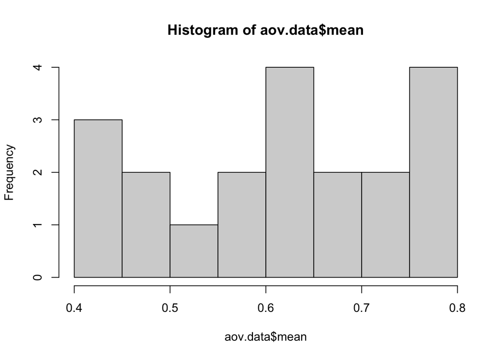

```
## The median value of the E recalled words is:  0.6285
```

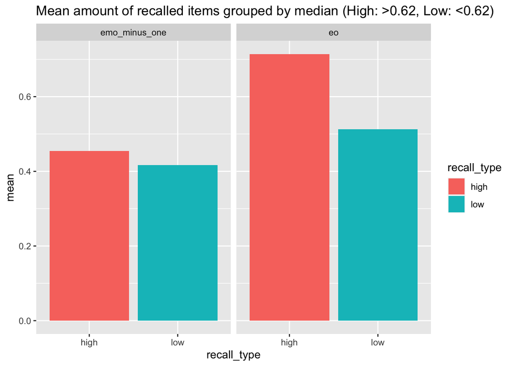

Now let’s put the data in a two-way ANOVA with item (E oddball / E-1) x recall type (high / low ). Recall probability is the average recall values for that specific E word.

The data going into the ANOVA is the following:

| item_who | word_who | variable | n | mean | ci | recall_type |
| --- | --- | --- | --- | --- | --- | --- |
| emo_minus_one | amputaci�n | recall | 70 | 0.443 | 0.119 | high |
| emo_minus_one | c�ncer | recall | 70 | 0.429 | 0.119 | high |
| emo_minus_one | morgue | recall | 70 | 0.357 | 0.115 | high |
| emo_minus_one | nazi | recall | 70 | 0.486 | 0.120 | high |
| emo_minus_one | sida | recall | 70 | 0.429 | 0.119 | high |
| emo_minus_one | suicida | recall | 70 | 0.514 | 0.120 | high |
| emo_minus_one | terrorista | recall | 70 | 0.486 | 0.120 | high |
| emo_minus_one | traidor | recall | 70 | 0.443 | 0.119 | high |
| emo_minus_one | tumor | recall | 70 | 0.671 | 0.113 | high |
| emo_minus_one | violaci�n | recall | 70 | 0.286 | 0.108 | high |

[output cut: 30 more lines]

Results of the ANOVA and follow-up t-test:

|  | Effect | DFn | DFd | F | p | p<.05 | ges |
| --- | --- | --- | --- | --- | --- | --- | --- |
| 1 | item_who | 1 | 36 | 52.334 | 1.62e-08 | * | 0.592 |
| 2 | recall_type | 1 | 36 | 23.601 | 2.32e-05 | * | 0.396 |
| 3 | item_who:recall_type | 1 | 36 | 11.158 | 2.00e-03 | * | 0.237 |

|  | item_who | .y. | group1 | group2 | n1 | n2 | p | p.signif | p.adj | p.adj.signif |
| --- | --- | --- | --- | --- | --- | --- | --- | --- | --- | --- |
| 1 | emo_minus_one | mean | high | low | 10 | 10 | 3.45e-01 | ns | 3.45e-01 | ns |
| 2 | eo | mean | high | low | 10 | 10 | 3.43e-06 | **** | 3.43e-06 | **** |

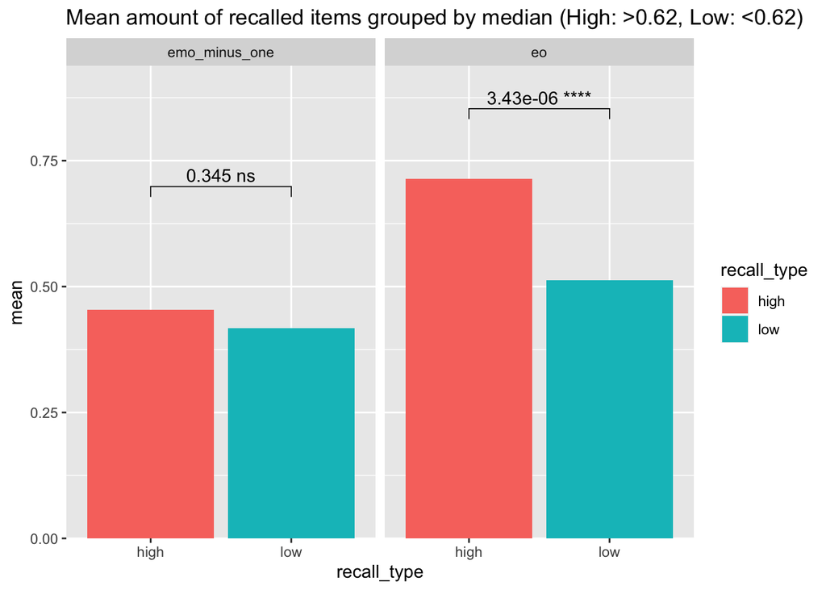

Control for memory for control items in the list

|  | subject | recall | item_who | word_who | list |
| --- | --- | --- | --- | --- | --- |
| 1 | 4 | 1 | eo | tumor | 2 |
| 1401 | 4 | 0 | emo_minus_one | tumor | 2 |
| 2 | 4 | 0 | eo | hambruna | 12 |
| 1402 | 4 | 0 | emo_minus_one | hambruna | 12 |
| 3 | 4 | 0 | eo | ceguera | 13 |
| 1403 | 4 | 0 | emo_minus_one | ceguera | 13 |
| 4 | 4 | 1 | eo | amputaci�n | 17 |
| 1404 | 4 | 0 | emo_minus_one | amputaci�n | 17 |
| 5 | 4 | 0 | eo | sufrimiento | 20 |
| 1405 | 4 | 0 | emo_minus_one | sufrimiento | 20 |

[output cut: 2790 more lines]

|  | subject | list | item_who | recall |
| --- | --- | --- | --- | --- |
| 1 | 4 | 2 | eo | 1 |
| 1401 | 4 | 2 | emo_minus_one | 0 |
| 2 | 4 | 12 | eo | 0 |
| 1402 | 4 | 12 | emo_minus_one | 0 |
| 3 | 4 | 13 | eo | -1 |
| 1403 | 4 | 13 | emo_minus_one | -1 |
| 4 | 4 | 17 | eo | 1 |
| 1404 | 4 | 17 | emo_minus_one | 0 |
| 5 | 4 | 20 | eo | 0 |
| 1405 | 4 | 20 | emo_minus_one | 0 |

[output cut: 2790 more lines]

| item_who | word_who | variable | n | mean | sd |
| --- | --- | --- | --- | --- | --- |
| eo | ahogado | recall | 70 | -0.071 | 0.709 |
| emo_minus_one | ahogado | recall | 70 | -0.186 | 0.728 |
| eo | amputaci�n | recall | 70 | 0.200 | 0.554 |
| emo_minus_one | amputaci�n | recall | 70 | -0.114 | 0.603 |
| eo | asesino | recall | 70 | 0.114 | 0.808 |
| emo_minus_one | asesino | recall | 70 | -0.014 | 0.712 |
| eo | asfixia | recall | 70 | 0.200 | 0.672 |
| emo_minus_one | asfixia | recall | 70 | 0.029 | 0.659 |
| eo | ceguera | recall | 70 | -0.100 | 0.725 |
| emo_minus_one | ceguera | recall | 70 | -0.157 | 0.715 |

[output cut: 30 more lines]

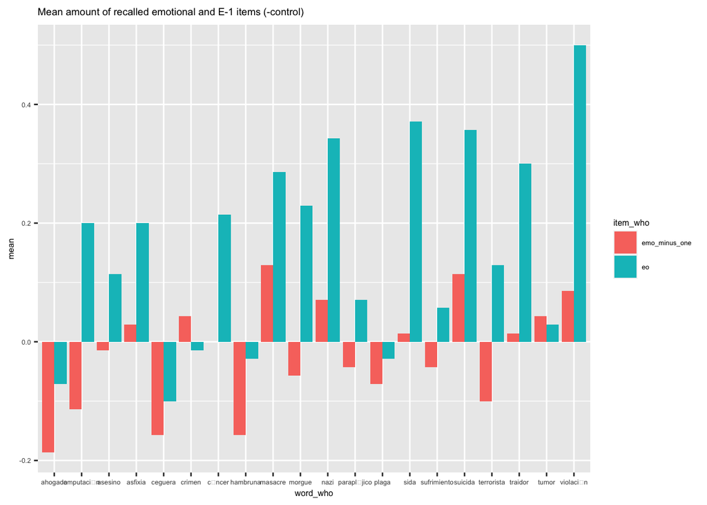

Now group by the words by the initial items /lists defined earlier that were better recalled than others:

- high recall = amputación, cáncer, morgue, nazi, sida, suicida, terrorista, traidor, tumor, violación
- low recall = ahogado, asesino, asfixia, ceguera, crimen, hambruna, masacre, parapléjico, plaga, sufrimiento

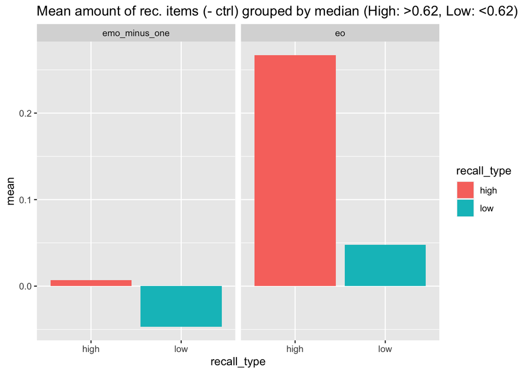

Grouping the items from those emotional lists that had high vs. low recall: in high recall lists, the E-1 nouns were recalled equally than control words (i.e. mean recall = 0), in low recall lists memory for E-1 words was lower than for C words (because probably overall worse recall in the list).

But a t-test between E-1 recall in high vs. low lists is not significant

Therefore, even when splitting the lists by high / low emotional oddball recall does not show a retrograde amnesic effect. This is in line with our Bayesian stats results that provide strong support of no peri-oddball amnesic effects in this version of the task.

|  | item_who | .y. | group1 | group2 | n1 | n2 | statistic | df | p | p.adj | p.adj.signif |
| --- | --- | --- | --- | --- | --- | --- | --- | --- | --- | --- | --- |
| 1 | emo_minus_one | mean | high | low | 10 | 10 | 1.161954 | 9 | 0.275 | 0.275 | ns |
| 2 | eo | mean | high | low | 10 | 10 | 3.382866 | 9 | 0.008 | 0.008 | ** |

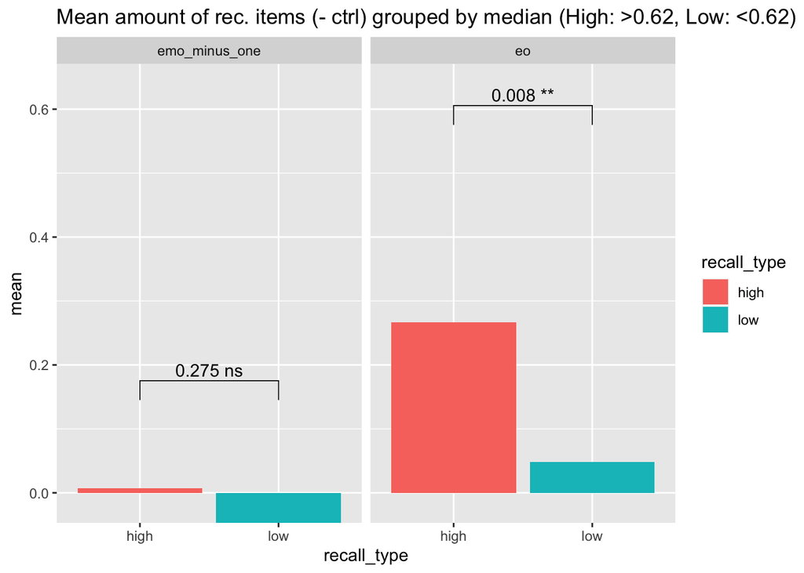

Looking at E-1 recall for the items that elicit ‘amnesia’: ‘amputaci�n’, ‘asesino’, ‘morgue’, ‘parapl�jico’, ‘sufrimiento’, ‘terrorista’

vs. the ones that ‘did not elicit amnesia’: ‘c�ncer’, ‘nazi’, ‘sida’, ‘suicida’, ‘traidor’, ‘tumor’,‘violaci�n’, ‘ahogado’, ‘asfixia’, ‘ceguera’, ‘crimen’, ‘hambruna’, ‘masacre’, ‘plaga’

Even though it’s 6 vs. 14 words, ran an unpaired t-test and there are no differences in E-1 recall within the two groups, so the ‘amnesia’ we see is not strong enough to be different from other items.

|  | Effect | DFn | DFd | F | p | p<.05 | ges |
| --- | --- | --- | --- | --- | --- | --- | --- |
| 1 | amnesia_type | 1 | 18 | 1.892 | 0.186 |  | 0.095 |

# CRP curves divided by the ‘amnesic’ vs. ‘non-amnesic’ items above

Now, look at CRP curves separating by items that caused ‘amnesia’ i.e. amputación, asesino, morgue, parapléjico, sufrimiento, terrorista vs. all other emotional lists.

Conclusion: No differences in CRPs.

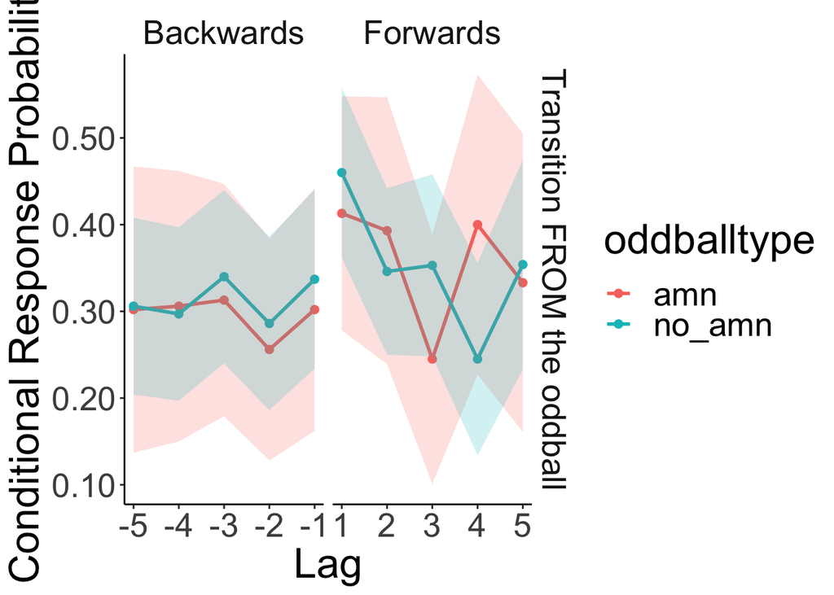

# CRP curves divided by ‘amnesia’ vs. ‘no amnesia’ when the E oddball was recalled > controls

CRP curves separating by items that have ‘amnesia’ vs. ‘no amnesia’ only for those lists when the Emo Odd were better recalled than control items.

Amnesia: amputación, asesino, morgue, parapléjico, sufrimiento, terrorista

No amnesia: cáncer, nazi, sida, suicida, traidor, tumor, violación, asifixia, masacre

Conclusion: No differences in CRPs.

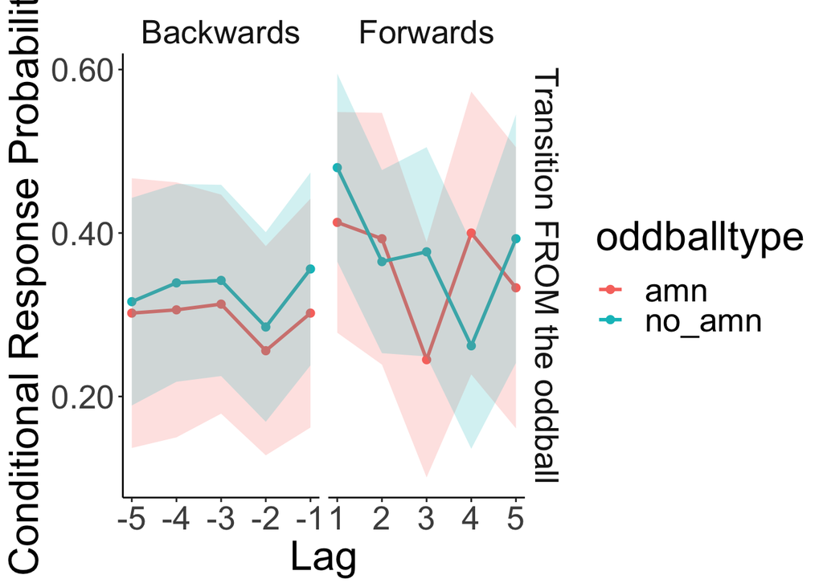

# CRP curves divided high vs. low E recall

Now, look at CRP curves separating by items that have high vs. low recall (by median split).

High recall: amputación, cáncer, morgue, nazi, sida, suicida, terrorista, traidor, tumor, violación

Low recall: ahogado, asesino, asfixia, ceguera, crimen, hambruna, masacre, parapléjico, plaga, sufrimiento

Conclusion: No differences in CRPs.

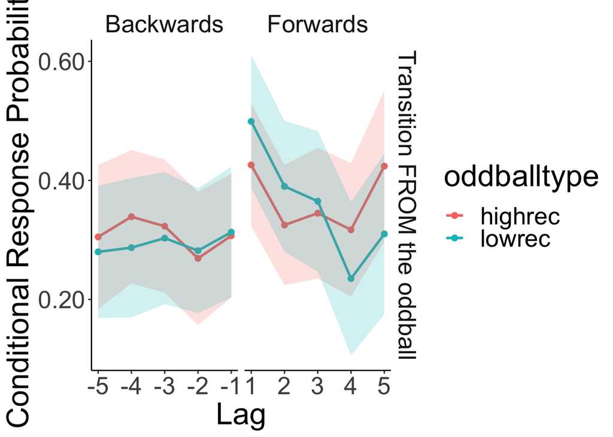